# Tarea 1 EYP2117

# Pregunta 1

Considere el volumen generado por:

$$\iint_R x\cdot y^2\sqrt{x^2+y^3} \,dR$$

donde $R = [0,3]\times[0,2]$

Importamos los paquetes a utilizar

```r
library(pracma)
```

### a) Realice en R un gráfico que muestre el volumen de interés.

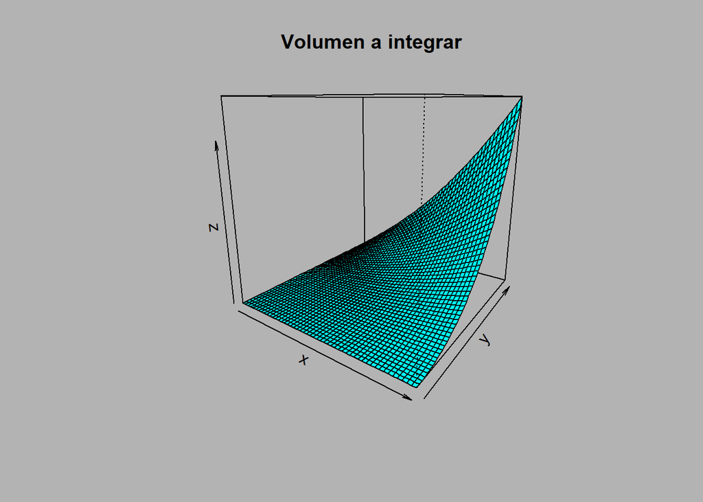

```r
set.seed(2117)
integral <- function(x,y){
  hx <-  x*y^2*sqrt(x^2+y^3)
  return(hx)
}

rango_x <- seq(0,3,length = 50)
rango_y <- seq(0,2,length = 50)
z <- outer(rango_x,rango_y,integral)

par(bg = "gray70")
persp(rango_x, rango_y, z,
      main = "Volumen a integrar",
      xlab = "x",
      ylab = "y",
      theta = 35, phi = 15,
      col = "cyan"
      )
```

### b) Interesa estimar la integral mediante la simulación de variables aleatorias con distribución Uniforme(0,1). Derive analíticamente la forma que toma la expresión en el nuevo hipercubo.

Consideremos la expresion

$$\theta = \int_{a}^{b}\dots\int_{c}^{d}g(x_1,x_2,\dots,x_n)\,dx_1\,dx_2\cdots \,dx_n$$

sabemos que $U_1,U_2 \overset{\text{iid}}{\sim} U(0,1)$, por lo que

$$\mathbb{E}(g(u_1,u_2,\cdots,u_n)) = \int_{0}^{1}\cdots\int_{0}^{1}g(u_1,u_2,\cdots,u_n)(b-a)\cdots(d-c)\,du_1\,du_2\cdots\,du_n$$

así, podemos aproximar $\theta$ generando $m$ vectores $U(0,1)$ de largo $n$

$$\frac{1}{n}\sum_{i = 1}^{m}g(u_{i1},g_{i2},\cdots,g_{in}).$$

Ahora, en nuestro caso, $\theta$ está representado por

$$\theta = \int_{0}^{3}\int_{0}^{2}x\cdot y^2\sqrt{x^2+y^3}\,dy\,dx$$

luego, generamos $U_1,U_2\overset{\text{iid}}{\sim}U(0,1)$ para así, llegar a la expresión

$$\int_{0}^{1}\int_{0}^{1}g(u_1,u_2)\cdot(3-0)(2-0)\,du_1\,du_2$$

con $g(u_1,u_2) = u_1\cdot u_2^2\sqrt{u_1^2+u_2^3}$.

Finalmente, aproximamos el valor de $\theta$ de la forma

$$\hat{\theta}=\frac{1}{n}\sum_{i = 1}^{m}g(u_{i1},u_{i2})$$

### c) Escriba en R un programa que estime el valor de la integral en base a vectores aleatorios de tamaño $n$.

```r
estimador <- function(N){
  U1 <- runif(N,0,3)
  U2 <- runif(N,0,2)
  hx <- U1*U2^2*sqrt(U1^2+U2^3)*6
  return(mean(hx))
}
```

### d) Estime el valor de la integral en vase muestras de tamaño $n = 10^2$, $10^3$, $10^4$. Compare los resultados con el valor real obtenido mediante la función `integral2` de la libreria `pracma` . Comente

```r
N_1 <- 10^2
N_2 <- 10^3
N_3 <- 10^4
#Para n = 10^2
estimador(N_1)
```

```
[1] 39.7011
```

```r
#Para n = 10^3
estimador(N_2)
```

```
[1] 34.19873
```

```r
#Para n = 10^4
estimador(N_3)
```

```
[1] 34.04527
```

```r
#Valor real
valor_real <- pracma::integral2(integral, 0, 3, 0, 2)
valor_real[1]
```

```
$Q
[1] 34.1137
```

Podemos apreciar que para el caso cuando $n = 10^2$, este sobre estima el valor de la integral.

Para $n = 10^3$, al igual que el caso anterior, sobre estimó por unos decimales el valor real.

Con estos test podemos concluir que a medida que $n \to \infty$, se genera una mejor estimación. Sin embargo, no hay que olvidar que estamos buscando una aproximación al valor real y además estamos trabajando con la aleatoriedad de los vectores generados $U_1,U_2 \overset{\text{iid}}{\sim} U(0,1)$.

# Pregunta 2

Para el cálculo de la esperanza $\mathbb{E}_f[h(x)]$ cuando $f$ es la distribución Normal(0,1) y $h(x) = \exp\left(\frac{-(x-3)^2}{2}\right)+\exp\left(\frac{-(x-6)^2}{2}\right)$:

### a) Demuestre que $\mathbb{E}_f[h(x)]$ se puede calcular en forma cerrada y obtenga su valor

Sabemos que cuando $X \sim Normal(0,1)$, su pdf viene de la forma:

$$f(x) = \dfrac{1}{\sqrt{2\pi}}\cdot \exp\left(\dfrac{-x^2}{2}\right)$$

por lo que para el cálculo de $\mathbb{E}_f[h(x)]$, esto se ve representado como

$$\begin{align*}
\mathbb{E}_f[h(x)] &= \int_{-\infty}^{\infty}\dfrac{1}{\sqrt{2\pi}}\cdot \exp\left(\dfrac{-x^2}{2}\right)\cdot\left(\exp\left(\frac{-(x-3)^2}{2}\right)+\exp\left(\frac{-(x-6)^2}{2}\right)\right)\,dx\\
&=\dfrac{1}{\sqrt{2\pi}}\cdot\int_{-\infty}^{\infty}\exp\left(\dfrac{-x^2}{2}\right)\cdot\left(\exp\left(\frac{-(x-3)^2}{2}\right)+\exp\left(\frac{-(x-6)^2}{2}\right)\right)\,dx\\
&=\dfrac{1}{\sqrt{2\pi}}\cdot\int_{-\infty}^{\infty}\exp\left(\dfrac{-x^2-(x^2-6x+9)}{2}\right)+\exp\left(\dfrac{-x^2-(x^2-12x+36)}{2}\right)\,dx\\
&=\dfrac{1}{\sqrt{2\pi}}\cdot\int_{-\infty}^{\infty}\exp\left(\dfrac{-2x^2+6x-9}{2}\right)+\exp\left(\dfrac{-2x^2+12x-36}{2}\right)\,dx\\
&=\dfrac{1}{\sqrt{2\pi}}\cdot\left[\exp\left(\frac{-9}{4}\right)\cdot\int_{-\infty}^{\infty}\exp\left(-\left(x-\frac{3}{2}\right)^2\right)+\exp(-9)\cdot\int_{-\infty}^{\infty}\exp\left(-(x-3)^2\right)\right]\,dx\\
\end{align*}$$

luego, usando la generalización de la integral de una función gaussiana

$$\int_{-\infty}^{\infty}\exp(-a(x+b))^2\,dx = \sqrt{\dfrac{\pi}{a}}$$

en nuestro caso

$$\begin{align*}
&\int_{-\infty}^{\infty}\exp\left(-\left(x-\frac{3}{2}\right)\right)^2\,dx = \sqrt{\pi}\\
\\
&\int_{-\infty}^{\infty}\exp\left(-\left(x-3\right)\right)^2\,dx = \sqrt{\pi}
\end{align*}$$

reemplazando en la expresión

$$\begin{align*}
\mathbb{E}_f[h(x)] &= \dfrac{1}{\sqrt{2\pi}}\left[\exp\left(-\frac{9}{4}\right)\cdot\sqrt{\pi}+\exp\left(-9\right)\sqrt{\pi}\right]\\
&= \dfrac{1}{\sqrt{2}}\left[\exp\left(-\frac{9}{4}\right)+\exp(-9)\right]
\end{align*}$$

así, llegamos a que $\mathbb{E}_f[h(x)]$ se puede calcular de forma cerrada.

### b) Implemente en R una aproximación regular de Monte Carlo basada en una muestra Normal(0,1)

Por lo visto en clases, sabemos que podemos generar $g_i \sim Normal(0,1)$ dado $U_i \sim Uniforme(0,1)$, $i = 1,2,...$ aplicando la transformación

$$\begin{align*}
0 &< U < 1\\
0 &< \frac{U}{1-U} < \infty\\
-\infty &< \log\left(\frac{U}{1-U}\right) < \infty
\end{align*}$$

en donde $g = log\left(\frac{U}{1-U}\right) \sim Normal(0,1)$.

```r
sim <- function(N){
  U <- runif(N)
  g <- log(U/(1-U))

  hx <- (1/sqrt(2*pi)*exp(-g^2/2)*(exp(-(g-3)^2/2)+
          exp(-(g-6)^2/2)))*1/(U*(1-U))

  return(mean(hx))
}
```

### c) Realice un gráfico que permita visualizar la estimación de $\mathbb{E}_f[h(x)]$ a medida que aumenta el tamaño de la muestra utilizada con este fin. Comience con una muestra de tamaño 1, a la que se le agrega nuesvas realizaciones (de a 1) hasta llegar a $10^4$. Comente

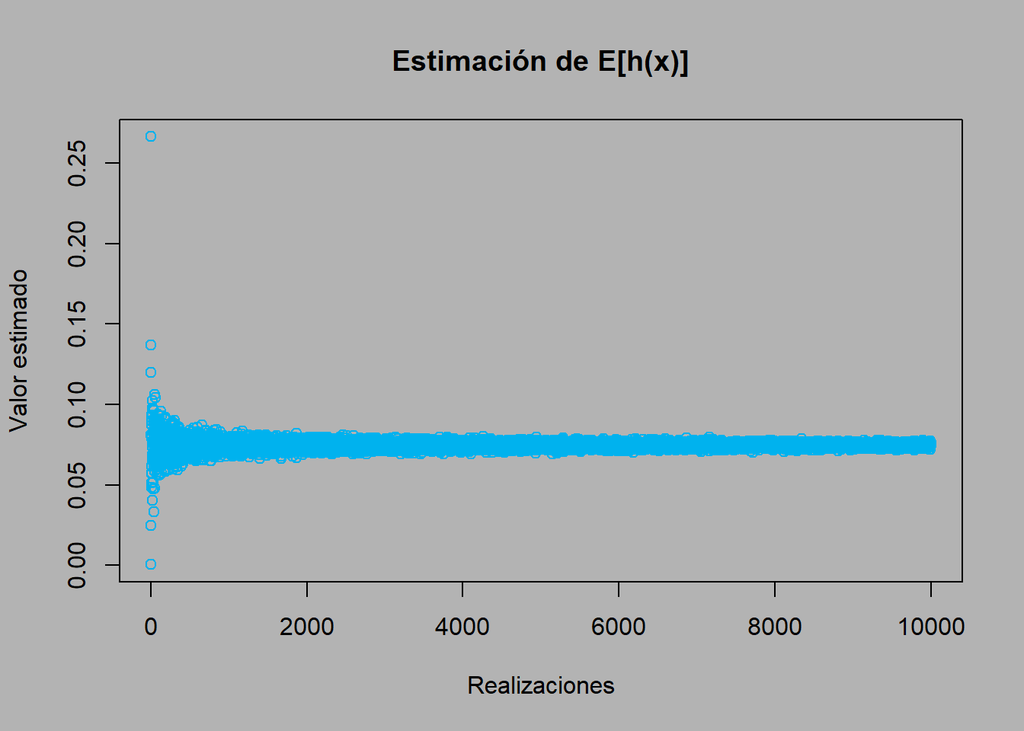

```r
N <- 10^4
seq <- seq(1,N)
muestras <- c()
for(i in 1:N){
  muestras <- append(muestras, sim(i))
}
par(bg = "gray70")
plot(seq, muestras, xlab = "Realizaciones", ylab = "Valor estimado",
     main = "Estimación de E[h(x)]", col = "deepskyblue2")
```

Podemos apreciar que a medida que se aumentan las realizaciones, el gráfico de dispersión va convirgiendo a una aproximación más precisa de la integral.

### d) Realice un gráfico que permita visualizar la precisión de la estimación de $\mathbb{E}_f[h(x)]$ a medida que aumenta el tamaño de la muestra utilizada con este fin. Comience con una muestra de tamaño 1, a la que se le agrega nuevas realizaciones (de a 1) hasta llegar a $10^4$. Comente.

Para encontrar el valor real de la integral, la calculamos usando la libreria `pracma`, con la función `integral`

```r
funcion_esp <- function(x){
  hx <- (1/sqrt(2*pi)*exp(-x^2/2)*(exp(-(x-3)^2/2)+exp(-(x-6)^2/2)))
  return(hx)
}

(valor_real_esp <- pracma::integral(funcion_esp,-Inf,Inf))
```

```
For infinite domains Gauss integration is applied!
```

```
[1] 0.07461577
```

ahora, podemos realizar el gráfico de la precisión de la estimación.

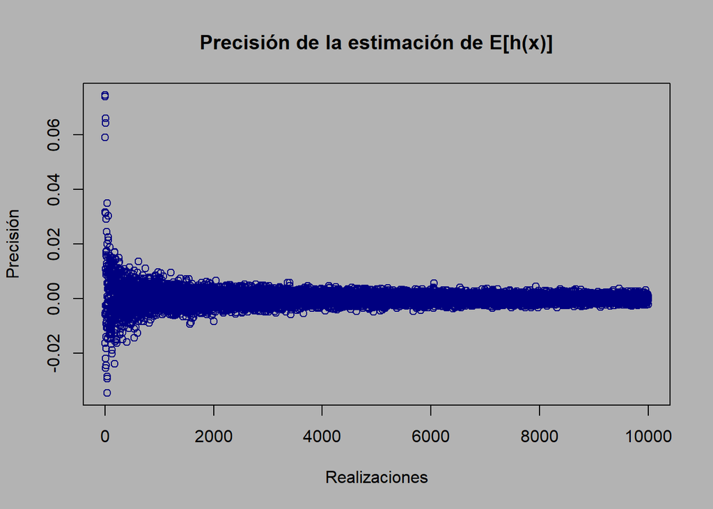

```r
N_1 <- 10^4
seq_1 <- seq(1,N_1)
precision <- c()
for(i in 1:N_1){
  precision <- append(precision, valor_real_esp - sim(i))
}
par(bg = "gray70")
plot(seq_1, precision, xlab = "Realizaciones", ylab = "Precisión",
     main = "Precisión de la estimación de E[h(x)]", col = "navy")
```

Apreciamos al igual que el gráfico anterior, a medida que aumentan las simulaciones, la precisión va tendiendo a 0, es decir, se acerca cada vez mas al valor real.

# Pregunta 3

Considere una variable aleatoria, $X$, con función de densidad dada por:

$$f(x) = \begin{cases}
0 & \text{si}\ & x<2a\quad\text{o}\quad x\geq 2b\\
\dfrac{x-2a}{(b-a)^2} & \text{si} & 2a \leq x < a+b\\
\dfrac{(2b-x)}{(b-a)^2} & \text{si} & a+b \leq x < 2b
\end{cases}$$

### a) Derive la función de distribución de la variable aleatoria $X$.

- Para $x < 2a \text{ y } x \geq 2b$:

$$F(x) = \int_{-\infty}^{x}0\,dt = 0$$

- Para $2a \leq x < a+b$:

$$\begin{align*}
F(x) &= \int_{2a}^{x}\dfrac{t-2a}{(b-a)^2}\,dt\\
&=\dfrac{1}{(b-a)^2}\cdot\int_{2a}^{x}t-2a\,dt\\
&=\dfrac{1}{(b-a)^2}\cdot\left(\int_{2a}^{x}t\,dt -\int_{2a}^{x}2a\,dt\right)\\
&=\dfrac{1}{(b-a)^2}\cdot\left(\dfrac{x^2}{2}-2a^2-(2ax-4a^2)\right)\\
&=\dfrac{4a^2-4ax+x^2}{2(b-a)^2}
\end{align*}$$

- Para $a+b \leq x < 2b$:

$$\begin{align*}
F(x) &= \int_{2a}^{a+b}\dfrac{t-2a}{(b-a)^2}\,dt+\int_{a+b}^{x}\dfrac{2b-t}{(b-a)^2}\,dt\\
&= \dfrac{1}{2}+\dfrac{1}{(b-a)^2}\int_{b+a}^{x}2b-t\,dt\\
&= \dfrac{1}{2}+\dfrac{1}{(b-a)^2}\left(\int_{b+a}^{x}2b\,dt-\int_{b+a}^{x}t\,dt\right)\\
&= \dfrac{1}{2}+\dfrac{1}{(b-a)^2}\left(-\dfrac{x^2-b^2-2ab-a^2}{2}+2bx-2b(a+b)\right)\\
&= \dfrac{1}{2}-\dfrac{x^2-4bx+3b^2-a^2+2ab}{2(b-a)^2}
\end{align*}$$

- Para $x\geq2b$:

$$F(x) = \int_{-\infty}^{x}f(t)\,dt = 1$$

Así, la función de distribución queda de la forma

$$F(x) =\begin{cases}
0 &\text{si}\ &x<2a \quad\text{o}\quad x\geq2b\\
\dfrac{4a^2-4ax+x^2}{2(b-a)^2} &\text{si}\ &2a\leq x<a+b\\
\dfrac{1}{2}-\dfrac{x^2-4bx+3b^2-a^2+2ab}{2(b-a)^2} &\text{si}\ & a+b \leq x < 2b\\
1 &\text{si}\ &x\geq 2b
\end{cases}$$

### b) Muestre que, de acuerdo al método de la transformada inversa, la simulación de valores provinientes de $f(x)$ se realiza mediante:

$$X = \begin{cases}
2a+(b-a)\sqrt{2U}\quad&\text{si}\quad 0\leq U<\frac{1}{2}\\
2b+(a-b)\sqrt{2(1-U)}\quad&\text{si}\quad \frac{1}{2}\leq U <1
\end{cases}$$

Recordando que el método de la transformada inversa para variables aleatorias continuas era de la forma

$$U \overset{\text{iid}}{\sim} U(0,1),\text{tal que } X = F^{-1}(U)$$

Es decir, dada una función de distribución $F(x)$, la igualamos a la variable $U$ y calculamos su inversa.

Para $0 \leq U < \frac{1}{2}$:

$$\begin{align*}
U &= \dfrac{4a^2-4ax+x^2}{2(b-a)^2}\\
4a^2-4ax+x^2 &= 2U(b-a)^2\\
4a^2-4ax+x^2 &= 2a^2U-4ab+4b^2U\\
x^2-4ax+4a^2-&2b^2U+4abU-2a^2U = 0
\end{align*}$$
Aplicando la fórmula general para ecuaciones de segundo grado:

$$\begin{align*}
x &= \dfrac{-(-4a)\pm\sqrt{(-4a)^2-4\cdot1\cdot(4a^2-2b^2U+4abU-2a^2U)}}{2\cdot1}\\
&= \dfrac{4a\pm\sqrt{4\cdot2U(b^2-2ab+a^2)}}{2}\\
&= 2a+(b-a)\sqrt{2U}
\end{align*}$$

Luego, para $\frac{1}{2}\leq U <1$:

$$\begin{align*}
U &= \dfrac{1}{2}-\dfrac{x^2-4bx+3b^2-a^2+2ab}{2(b-a)^2}\\
2U(b-a)^2 &= (b-a)^2-(x^2-4bx+3b^2-a^2+2ab)\\
2b^2U-4abU+2a^2U &= -x^2+4bx-2b^2+2a^2-4ab\\
-x^2+4bx-2b^2+2a^2-&4ab-2a^2U+4abU-2b^2U = 0
\end{align*}$$
Aplicando nuevamente la fórmula general para ecuaciones de segundo grado:

$$\begin{align*}
x &= \dfrac{-4b\pm\sqrt{(4b)^2-4\cdot-1(-2b^2+2a^2-4ab-2a^2U+4abU-2b^2U)}}{2\cdot-1}\\
&= \dfrac{-4b\pm\sqrt{8(b^2
a^2-2ab)-8U(a^2-2ab+b^2)}}{-2}\\
&= \dfrac{-4b\pm\sqrt{(a-b)^2(8-8U)}}{-2}\\
&= \dfrac{-4b + 2(a-b)\sqrt{2(1-U)}}{-2}\\
&= 2b+(a-b)\sqrt{2(1-U)}
\end{align*}$$

Finalmente, $X$ queda de la forma

$$X = \begin{cases}
2a+(b-a)\sqrt{2U}\quad&\text{si}\quad 0\leq U<\frac{1}{2}\\
2b+(a-b)\sqrt{2(1-U)}\quad&\text{si}\quad \frac{1}{2}\leq U <1
\end{cases}$$

### c) Escriba paso a paso el algoritmo para generar un valor de la variable aleatoria $X$ para cualquier valor de $a$ y $b$

El algoritmo que nos permite generar valores para la variable aleatoria $X$ sería

1. Generar un vector $U \sim U(0,1)$, de largo $N$.
2. Evaluar $U$ en la función $X$ según el valor que este tome, considerando los intervalos de la función por partes. Además de darle valores $a$, $b$ a la función para que retorne un valor numérico.
3. Almacenar en un vector los resultados para luego poder graficarlos y compararlos con los resultados reales.

### d) Implemente en R el algoritmo descrito en el apartado anterior.

```r
funcion_ppartes <- function(a,b,N){
  U <- runif(N)
  vector_respuesta <- NULL
  for(i in 1:N){
    if(U[i]<1/2){
      hx <- 2*a+(b-a)*sqrt(2*U[i])
      vector_respuesta <- c(vector_respuesta,hx)
    }else{
      hx <- 2*b+(a-b)*sqrt(2*(1-U[i]))
      vector_respuesta <- c(vector_respuesta,hx)
    }
  }
  return(vector_respuesta)
}
```

### e) Simule $10^4$ realizaciones de la variable aleatoria $X$, $a = 0$ y $b = 5$. Realice un histograma de la muestra obtenida y superponga la función $f(x)$.

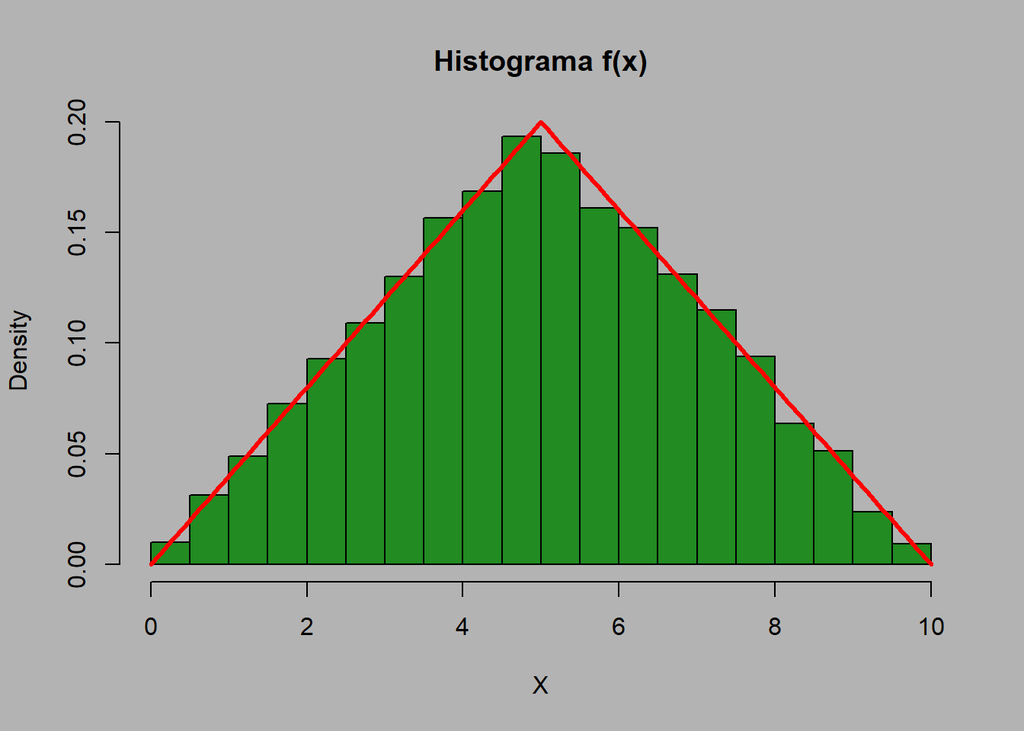

```r
N = 10^4
a = 0
b = 5

hx_1 <- function(x){
  hx <- x/25
  return(hx)
  }

hx_2 <- function(x){
  hx <- (10-x)/25
  return(hx)
}

aux <- funcion_ppartes(a,b,N)
par(bg = "gray70")
hist(aux, prob = T, main= "Histograma f(x)", col = "forestgreen", xlab = "X")
curve(hx_1, from=0, to=5, add = TRUE, col = "red", lwd = 3)
curve(hx_2, from=5, to=10, add = TRUE, col = "red", lwd = 3)
```